# Inferential Stats Assignment

Bryant

2022-11-13

# Question 1: Regex and Gif

Load our packages and data

```
## # A tibble: 260 × 3
##    participant_id regex   gif
##             <dbl> <chr>   <chr>
##  1              1 re[g]ex [g]if
##  2              2 re[g]ex [g]if
##  3              3 re[g]ex [g]if
##  4              4 re[g]ex [g]if
##  5              5 re[g]ex [g]if
##  6              6 re[g]ex [g]if
##  7              7 re[g]ex [g]if
##  8              8 re[g]ex [g]if
##  9              9 re[g]ex [g]if
## 10             10 re[g]ex [g]if
## # … with 250 more rows
```

## Visualize

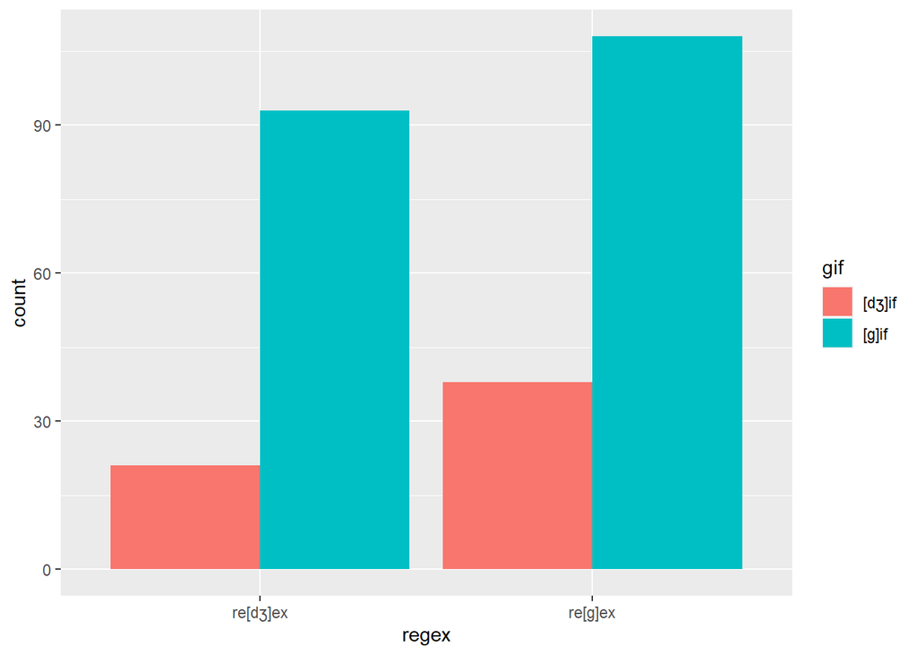

```r
ggplot(df, aes(regex, fill = gif)) +
  geom_bar(position=position_dodge())
```

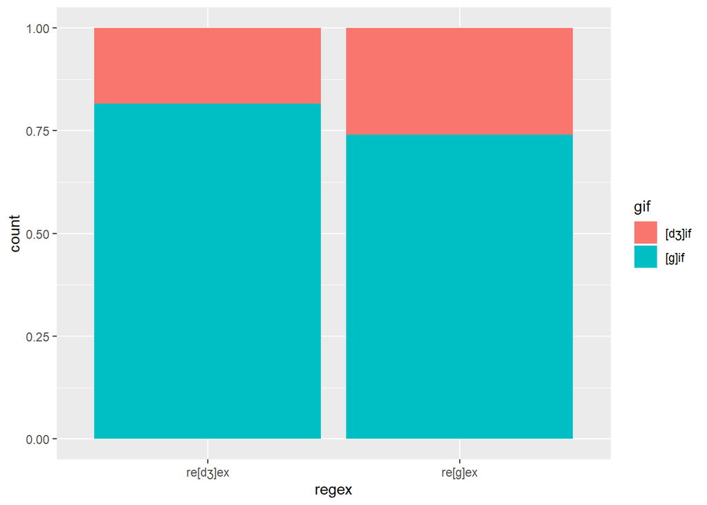

```r
ggplot(df, aes(regex, fill = gif)) +
  geom_bar(position = position_fill())
```

Here we can see that for both pronunciations of regex both pronunciations of gif are proportionally similar. Since we have two categorical variables we will run a chi^2 test and also find Cramer’s V to tell us if there is an association.

## Create Table

```r
df_tbl = xtabs(~gif + regex, data=df) %>%
  print()
```

```
##         regex
## gif      re[dʒ]ex re[g]ex
##   [dʒ]if       21      38
##   [g]if        93     108
```

## Run the chi-squared test

```r
rstatix::chisq_test(df_tbl)
```

```
## # A tibble: 1 × 6
##       n statistic     p    df method          p.signif
## * <int>     <dbl> <dbl> <int> <chr>           <chr>
## 1   260      1.70 0.192     1 Chi-square test ns
```

Our Chi^2 test gave us a p value of .192 which is much larger than .05. This tells us that we do not have any reason to reject the null hypothesis that there is a significant difference between the two distributions. We will now find Cramer’s V to further our investigation.

## Get cramer’s V

```r
vcd::assocstats(df_tbl)
```

```
##                     X^2 df P(> X^2)
## Likelihood Ratio 2.1404  1  0.14346
## Pearson          2.1112  1  0.14622
##
## Phi-Coefficient   : 0.09
## Contingency Coeff.: 0.09
## Cramer's V        : 0.09
```

Cramer’s V is .09 which is very close to 0 and tells us there is a very weak association between how people say gif and regex. We can conclude that we have not found any significant evidence to tell us that certain people will say re[dʒ]ex because they say [dʒ]if or visa versa. We also did not find any evidence to suggest there is a negative correlation between the two that people will say [dʒ]if if they say re[g]ex.

# Question 2: Subjective Frequencies

## Get the Mean and Standard Deviation

```r
ratings = languageR::ratings
ratings %>%
  group_by(Class) %>%
  summarize(n = n(),
            mean = mean(meanFamiliarity),
            sd = sd(meanFamiliarity))
```

```
## # A tibble: 2 × 4
##   Class      n  mean    sd
##   <fct>  <int> <dbl> <dbl>
## 1 animal    46  3.51 1.01
## 2 plant     35  4.37 0.846
```

## Visualize

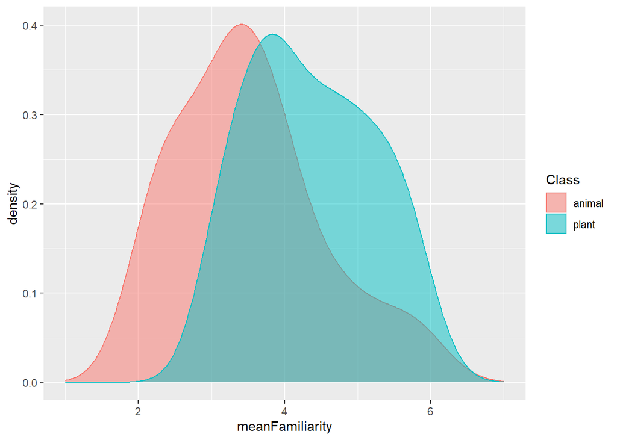

```r
ggplot(ratings, aes(meanFamiliarity, color=Class, fill=Class)) +
  xlim(1,7) +
  geom_density(alpha=.5)
```

These look kind of normal and they probably have the same standard deviation, but it is definitely worth testing our assumptions. We also note that our animal distribution looks overall “less” than our plant distribution for our t-test later.

## Check for normality

```r
ratings %>%
  group_by(Class) %>%
  rstatix::shapiro_test(meanFamiliarity)
```

```
## # A tibble: 2 × 4
##   Class  variable        statistic      p
##   <fct>  <chr>               <dbl>  <dbl>
## 1 animal meanFamiliarity     0.955 0.0722
## 2 plant  meanFamiliarity     0.948 0.0965
```

By the Shapiro test we see both our p values are over .05 so we can assume they are in fact normal enough to run our tests.

## Check if standard deviations are significantly different

```r
ratings %>%
  levene_test(meanFamiliarity ~ Class)
```

```
## # A tibble: 1 × 4
##     df1   df2 statistic     p
##   <int> <int>     <dbl> <dbl>
## 1     1    79     0.170 0.681
```

Clearly we pass the Levene test with a p value of .68.

## Run ANOVA

```r
ratings %>%
  anova_test(meanFamiliarity ~ Class)
```

```
## Coefficient covariances computed by hccm()
```

```
## ANOVA Table (type II tests)
##
##   Effect DFn DFd      F        p p<.05   ges
## 1  Class   1  79 16.441 0.000117     * 0.172
```

We can conclude with a p value of .0001 which is much less than our threshold of .05 that there is a significant difference in average familiarity between plants and animals.

## Run t-test

```r
ratings %>%
  t_test(meanFamiliarity ~ Class, var.equal = TRUE, alternative = "less")
```

```
## # A tibble: 1 × 8
##   .y.             group1 group2    n1    n2 statistic    df         p
## * <chr>           <chr>  <chr>  <int> <int>     <dbl> <dbl>     <dbl>
## 1 meanFamiliarity animal plant     46    35     -4.05    79 0.0000584
```

The t-test tells us the same thing as the ANOVA test, except here we could specify our prior assumption after viewing the two distributions that animal is less than plant. Using this assumption it is even more clear that there is a significant difference by our p value of .000058.

## Cohen’s D

```r
ratings %>%
  cohens_d(meanFamiliarity ~ Class, var.equal = TRUE)
```

```
## # A tibble: 1 × 7
##   .y.             group1 group2 effsize    n1    n2 magnitude
## * <chr>           <chr>  <chr>    <dbl> <int> <int> <ord>
## 1 meanFamiliarity animal plant   -0.909    46    35 large
```

This tells us that the means of the average familiarity between the two classes are almost a full standard deviation away from each other, which is large.